# Project 3 Solution

Ananya Bhaktaram

2024-10-20

# Background

**Due date: October 20th at 11:59pm**

The goal of this assignment is to practice wrangling special data types (including dates, character strings, and factors) and visualizing results while practicing our tidyverse skills.

# Load data

The datasets for this part of the assignment comes from [TidyTuesday](https://www.tidytuesday.com).

Data dictionary available here:

- https://github.com/rfordatascience/tidytuesday/tree/master/data/2020/2020-09-29

Specifically, we will explore album sales and lyrics from two artists (Beyoncé and Taylor Swift), The data are available from TidyTuesday from September 2020, which I have provided for you below:

```r
b_lyrics <- readr::read_csv("https://raw.githubusercontent.com/rfordatascience/tidytuesday/master/data/2020/2020-09-29/beyonce_lyrics.csv")
ts_lyrics <- readr::read_csv("https://raw.githubusercontent.com/rfordatascience/tidytuesday/master/data/2020/2020-09-29/taylor_swift_lyrics.csv")
sales <- readr::read_csv("https://raw.githubusercontent.com/rfordatascience/tidytuesday/master/data/2020/2020-09-29/sales.csv")
```

However, to avoid re-downloading data, we will check to see if those files already exist using an `if()` statement:

```r
library("here")
rds_files <- c("b_lyrics.RDS", "ts_lyrics.RDS", "sales.RDS")
## Check whether we have all 3 files
if (any(!file.exists(here("data", rds_files)))) {
    ## If we don't, then download the data
    b_lyrics <- readr::read_csv("https://raw.githubusercontent.com/rfordatascience/tidytuesday/master/data/2020/2020-09-29/beyonce_lyrics.csv")
    ts_lyrics <- readr::read_csv("https://raw.githubusercontent.com/rfordatascience/tidytuesday/master/data/2020/2020-09-29/taylor_swift_lyrics.csv")
    sales <- readr::read_csv("https://raw.githubusercontent.com/rfordatascience/tidytuesday/master/data/2020/2020-09-29/sales.csv")

    ## Then save the data objects to RDS files
    saveRDS(b_lyrics, file = here("data", "b_lyrics.RDS"))
    saveRDS(ts_lyrics, file = here("data", "ts_lyrics.RDS"))
    saveRDS(sales, file = here("data", "sales.RDS"))
}
```

The above code will only run if it cannot find the path to the `b_lyrics.RDS` on your computer. Then, we can just read in these files every time we knit the R Markdown, instead of re-downloading them every time.

Let’s load the datasets

```r
b_lyrics <- readRDS(here("data", "b_lyrics.RDS"))
ts_lyrics <- readRDS(here("data", "ts_lyrics.RDS"))
sales <- readRDS(here("data", "sales.RDS"))
```

# Part 1: Explore album sales

In this section, the goal is to explore the sales of studio albums from Beyoncé and Taylor Swift.

**Notes**

- In each of the subsections below that ask you to create a plot, you must create a title, subtitle, x-axis label, and y-axis label with units where applicable. For example, if your axis says “sales” as an axis label, change it to “sales (in millions)”.

## Part 1A

In this section, we will do some data wrangling.

```r
## Step 1: Organizing Data
# Load necessary libraries
library(stringr)
library(lubridate)
library(dplyr)
# Step 2: Define the regular expression in order to detect "(Country) [number]"

pattern <- "\\s*\\([A-Z]{2}\\)\\s*\\[\\d+\\]"

# Step 3: Clean the released column using the regular expression created in step 1

sales <- sales %>%
  mutate(cleaned_released = str_remove(released, pattern))

# Step 4: Convert the cleaned string column into a date class
sales <- sales %>%
  mutate(released_date = mdy(cleaned_released))  # Use mdy() since the format is "month day, year"

# Step 5: View the Results
print(sales)
```

```
## # A tibble: 48 × 10
##    artist       title        country    sales released  re_release label formats
##    <chr>        <chr>        <chr>      <dbl> <chr>     <chr>      <chr> <chr>
##  1 Taylor Swift Taylor Swift US       5720000 October … March 18,… Big … CD, CD…
##  2 Taylor Swift Fearless     WW      12000000 November… October 2… Big … CD, CD…
##  3 Taylor Swift Fearless     US       7180000 November… October 2… Big … CD, CD…
##  4 Taylor Swift Fearless     AUS       500000 November… October 2… Big … CD, CD…
##  5 Taylor Swift Fearless     UK        609000 November… October 2… Big … CD, CD…
##  6 Taylor Swift Speak Now    WW       5000000 October … <NA>       Big … CD, CD…
##  7 Taylor Swift Speak Now    US       4694000 October … <NA>       Big … CD, CD…
##  8 Taylor Swift Speak Now    UK        169281 October … <NA>       Big … CD, CD…
##  9 Taylor Swift Red          WW       6000000 October … <NA>       Big … CD, CD…
## 10 Taylor Swift Red          US       4465000 October … <NA>       Big … CD, CD…
## # ℹ 38 more rows
## # ℹ 2 more variables: cleaned_released <chr>, released_date <date>
```

```r
library(forcats)

# Step 6: Create a factor for country
sales <- sales %>%
  mutate(country = factor(country))

#Step 7: Collapse Levels into defined categories
sales <- sales %>%
  mutate(country = fct_collapse(country,
    US = "US",
    UK = "UK",
    World = c("World", "WW"),
    Other = c("AUS", "JPN", "CAN", "FRA", "FR")))

glimpse(sales)
```

```
## Rows: 48
## Columns: 10
## $ artist           <chr> "Taylor Swift", "Taylor Swift", "Taylor Swift", "Tayl…
## $ title            <chr> "Taylor Swift", "Fearless", "Fearless", "Fearless", "…
## $ country          <fct> US, World, US, Other, UK, World, US, UK, World, US, O…
## $ sales            <dbl> 5720000, 12000000, 7180000, 500000, 609000, 5000000, …
## $ released         <chr> "October 24, 2006", "November 11, 2008", "November 11…
## $ re_release       <chr> "March 18, 2008[34]", "October 27, 2009[40]", "Octobe…
## $ label            <chr> "Big Machine", "Big Machine", "Big Machine", "Big Mac…
## $ formats          <chr> "CD, CD+G (karaoke), DVD (karaoke), LP, digital downl…
## $ cleaned_released <chr> "October 24, 2006", "November 11, 2008", "November 11…
## $ released_date    <date> 2006-10-24, 2008-11-11, 2008-11-11, 2008-11-11, 2008…
```

```r
# Step 8: Transform sales column into a unit that stores album sales in millions of dollars

sales <- sales %>%
  mutate(sales_in_millions = sales / 1e6)  # Divide by a million

filtered_sales <- sales %>%
  filter(country %in% c("US", "UK", "World"))

# Step 9: Auto print as a tibble data frame
print(as_tibble(filtered_sales))
```

```
## # A tibble: 36 × 11
##    artist       title        country    sales released  re_release label formats
##    <chr>        <chr>        <fct>      <dbl> <chr>     <chr>      <chr> <chr>
##  1 Taylor Swift Taylor Swift US       5720000 October … March 18,… Big … CD, CD…
##  2 Taylor Swift Fearless     World   12000000 November… October 2… Big … CD, CD…
##  3 Taylor Swift Fearless     US       7180000 November… October 2… Big … CD, CD…
##  4 Taylor Swift Fearless     UK        609000 November… October 2… Big … CD, CD…
##  5 Taylor Swift Speak Now    World    5000000 October … <NA>       Big … CD, CD…
##  6 Taylor Swift Speak Now    US       4694000 October … <NA>       Big … CD, CD…
##  7 Taylor Swift Speak Now    UK        169281 October … <NA>       Big … CD, CD…
##  8 Taylor Swift Red          World    6000000 October … <NA>       Big … CD, CD…
##  9 Taylor Swift Red          US       4465000 October … <NA>       Big … CD, CD…
## 10 Taylor Swift Red          UK        693000 October … <NA>       Big … CD, CD…
## # ℹ 26 more rows
## # ℹ 3 more variables: cleaned_released <chr>, released_date <date>,
## #   sales_in_millions <dbl>
```

## Part 1B

In this section, we will do some more data wrangling followed by summarization using wrangled data from Part 1A.

1. Keep only album sales from the US.
2. Create a new column called `years_since_release` corresponding to the number of years since the release of each album from Beyoncé and Taylor Swift. This should be a whole number and you should round down to “14” if you get a non-whole number like “14.12” years. (**Hint**: you may find the `interval()` function from `lubridate` helpful here, but this not the only way to do this.)
3. Calculate the most recent, oldest, and the median years since albums were released for both Beyoncé and Taylor Swift.

```r
# Step 1: Filter from to only keep US Album sales
US_sales <- sales %>%
  filter(country %in% c("US"))

# Check that filtering was successful
print(as_tibble(US_sales))
```

```
## # A tibble: 13 × 11
##    artist       title           country  sales released re_release label formats
##    <chr>        <chr>           <fct>    <dbl> <chr>    <chr>      <chr> <chr>
##  1 Taylor Swift Taylor Swift    US      5.72e6 October… March 18,… Big … CD, CD…
##  2 Taylor Swift Fearless        US      7.18e6 Novembe… October 2… Big … CD, CD…
##  3 Taylor Swift Speak Now       US      4.69e6 October… <NA>       Big … CD, CD…
##  4 Taylor Swift Red             US      4.47e6 October… <NA>       Big … CD, CD…
##  5 Taylor Swift 1989            US      6.21e6 October… <NA>       Big … CD, CD…
##  6 Taylor Swift Reputation      US      2.3 e6 Novembe… <NA>       Big … CD, CD…
##  7 Taylor Swift Lover           US      1.09e6 August … <NA>       Repu… CD, LP…
##  8 Beyoncé      Dangerously in… US      5.10e6 June 23… <NA>       Colu… CD, LP…
##  9 Beyoncé      B'Day           US      3.61e6 Septemb… <NA>       Sony… CD, CD…
## 10 Beyoncé      I Am... Sasha … US      3.38e6 Novembe… <NA>       Musi… CD, CD…
## 11 Beyoncé      4               US      1.5 e6 June 24… <NA>       Park… CD, di…
## 12 Beyoncé      Beyoncé         US      2.51e6 Decembe… <NA>       Park… CD, CD…
## 13 Beyoncé      Lemonade        US      1.55e6 April 2… <NA>       Park… CD/DVD…
## # ℹ 3 more variables: cleaned_released <chr>, released_date <date>,
## #   sales_in_millions <dbl>
```

```r
# Create a new column called years_since_release

# Step 1: Determine today's date
current_date <- today()

# Step 2: Create a new column for years since release
US_sales <- US_sales %>%
  mutate(years_since_release = floor(as.numeric(interval(released_date, current_date) / years(1))))

# Check updated dataset
glimpse(US_sales)
```

```
## Rows: 13
## Columns: 12
## $ artist              <chr> "Taylor Swift", "Taylor Swift", "Taylor Swift", "T…
## $ title               <chr> "Taylor Swift", "Fearless", "Speak Now", "Red", "1…
## $ country             <fct> US, US, US, US, US, US, US, US, US, US, US, US, US
## $ sales               <dbl> 5720000, 7180000, 4694000, 4465000, 6215000, 23000…
## $ released            <chr> "October 24, 2006", "November 11, 2008", "October …
## $ re_release          <chr> "March 18, 2008[34]", "October 27, 2009[40]", NA, …
## $ label               <chr> "Big Machine", "Big Machine", "Big Machine", "Big …
## $ formats             <chr> "CD, CD+G (karaoke), DVD (karaoke), LP, digital do…
## $ cleaned_released    <chr> "October 24, 2006", "November 11, 2008", "October …
## $ released_date       <date> 2006-10-24, 2008-11-11, 2010-10-25, 2012-10-22, 20…
## $ sales_in_millions   <dbl> 5.720, 7.180, 4.694, 4.465, 6.215, 2.300, 1.085, …
## $ years_since_release <dbl> 17, 15, 13, 11, 9, 6, 5, 21, 18, 15, 13, 10, 8
```

```r
# Calculate Summary Statistics
album_stats <- US_sales %>%
  group_by(artist) %>%
  summarize(
    most_recent = max(years_since_release, na.rm = TRUE),
    oldest = min(years_since_release, na.rm = TRUE),
    median_years = median(years_since_release, na.rm = TRUE),
    album_title_most_recent = title[which.max(years_since_release)],  # Title of the most recent album
    album_title_oldest = title[which.min(years_since_release)]  # Title of the oldest album
  )

# Print Results
print(album_stats)
```

```
## # A tibble: 2 × 6
##   artist       most_recent oldest median_years album_title_most_recent
##   <chr>              <dbl>  <dbl>        <dbl> <chr>
## 1 Beyoncé               21      8           14 Dangerously in Love
## 2 Taylor Swift          17      5           11 Taylor Swift
## # ℹ 1 more variable: album_title_oldest <chr>
```

## Part 1C

Using the wrangled data from Part 1A:

1. Calculate the total album sales for each artist and for each `country` (only sales from the UK, US, and World).
   1. Note: assume that the World sales do not include the UK and US ones.
2. Using the total album sales, create a [percent stacked barchart](https://r-graph-gallery.com/48-grouped-barplot-with-ggplot2) using `ggplot2` of the percentage of sales of studio albums (in millions) along the y-axis for the two artists along the x-axis colored by the `country`.

```r
# Step 1: Calculate the total

total_sales <- filtered_sales %>%
  group_by(artist, country) %>%
  summarise(total_sales = sum(sales_in_millions))
print(total_sales)
```

```
## # A tibble: 6 × 3
## # Groups:   artist [2]
##   artist       country total_sales
##   <chr>        <fct>         <dbl>
## 1 Beyoncé      UK             5.24
## 2 Beyoncé      US            17.7
## 3 Beyoncé      World         34.5
## 4 Taylor Swift UK             3.32
## 5 Taylor Swift US            31.7
## 6 Taylor Swift World         40.8
```

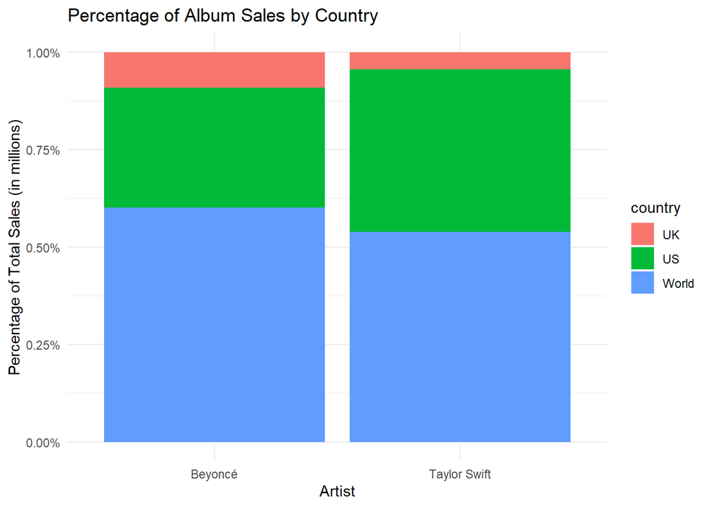

```r
# Creating a percent stacked bar chart in ggplot2
# Load necessary libraries
library(dplyr)
library(ggplot2)

# Step 1: Calculate percentage of sales for each country for each artist
total_sales <- total_sales %>%
  group_by(artist) %>%
  mutate(percentage = total_sales/ sum(total_sales) * 100)

# Step 2: Create a percent stacked bar chart using ggplot2
ggplot(total_sales, aes(x = artist, y = percentage, fill = country)) +
  geom_bar(stat = "identity", position = "fill") + # "fill" for percent stacked bar
  scale_y_continuous(labels = scales::percent_format(scale = 1)) + # Format y-axis as percentages
  labs(
    title = "Percentage of Album Sales by Country",
    x = "Artist",
    y = "Percentage of Total Sales (in millions)",
    fill = "country"
  ) +
  theme_minimal()
```

## Part 1D

Using the wrangled data from Part 1A, use `ggplot2` to create a bar plot for the sales of studio albums (in millions) along the x-axis for each of the album titles along the y-axis.

**Note**:

- You only need to consider the global World sales (you can ignore US and UK sales for this part). Hint: how would you abbreviate *WorldWide*?
- The title of the album must be clearly readable along the y-axis.
- Each bar should be colored by which artist made that album.
- The bars should be ordered from albums with the most sales (top) to the least sales (bottom) (**Note**: you must use functions from `forcats` for this step).

```r
# Step 1: Filter data to only include world sales

world_sales <- filtered_sales %>%
  filter(country=="World") %>%
  group_by(title, artist) %>%
  summarise(total_sales = sum(sales_in_millions, na.rm = TRUE)) %>%
  ungroup()
print(world_sales)
```

```
## # A tibble: 11 × 3
##    title                artist       total_sales
##    <chr>                <chr>              <dbl>
##  1 1989                 Taylor Swift        10.1
##  2 B'Day                Beyoncé              8
##  3 Beyoncé              Beyoncé              5
##  4 Dangerously in Love  Beyoncé             11
##  5 Fearless             Taylor Swift        12
##  6 I Am... Sasha Fierce Beyoncé              8
##  7 Lemonade             Beyoncé              2.5
##  8 Lover                Taylor Swift         3.2
##  9 Red                  Taylor Swift         6
## 10 Reputation           Taylor Swift         4.5
## 11 Speak Now            Taylor Swift         5
```

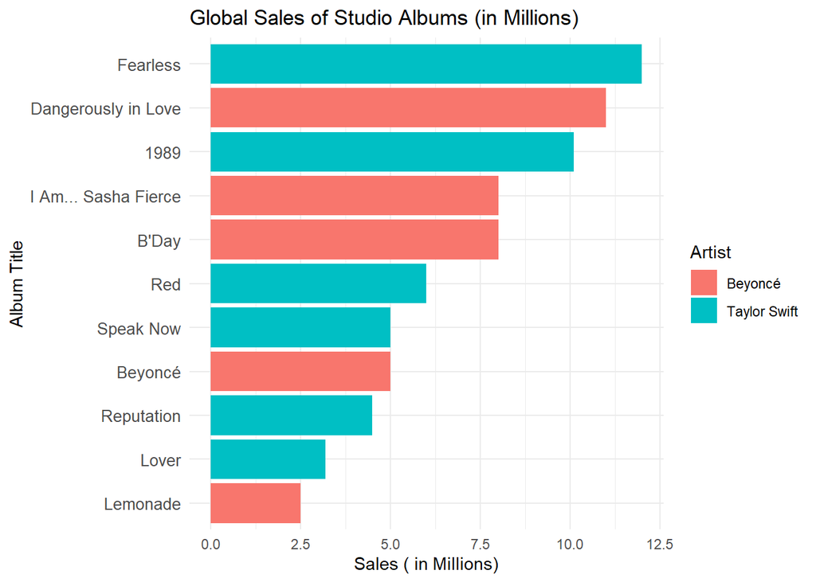

```r
# Step 2: Reorder album sales by total sales in descending order
world_sales <- world_sales %>%
  mutate(title = fct_reorder(title, total_sales))

# Step 3: Create the bar plot

ggplot(world_sales, aes(x = total_sales, y = title, fill = artist)) +
  geom_bar(stat = "identity") +
  labs(
    title = "Global Sales of Studio Albums (in Millions)",
    x = "Sales ( in Millions)",
    y = "Album Title",
    fill = "Artist"
  ) +
  theme_minimal() +
  theme(axis.text.y = element_text(size = 10))  # Adjust text size for readability
```

## Part 1E

Using the wrangled data from Part 1A, use `ggplot2` to create a scatter plot of sales of studio albums (in millions) along the y-axis by the released date for each album along the x-axis.

**Note**:

- The points should be colored by the artist.
- There should be three scatter plots (one for UK, US and world sales) faceted by rows.

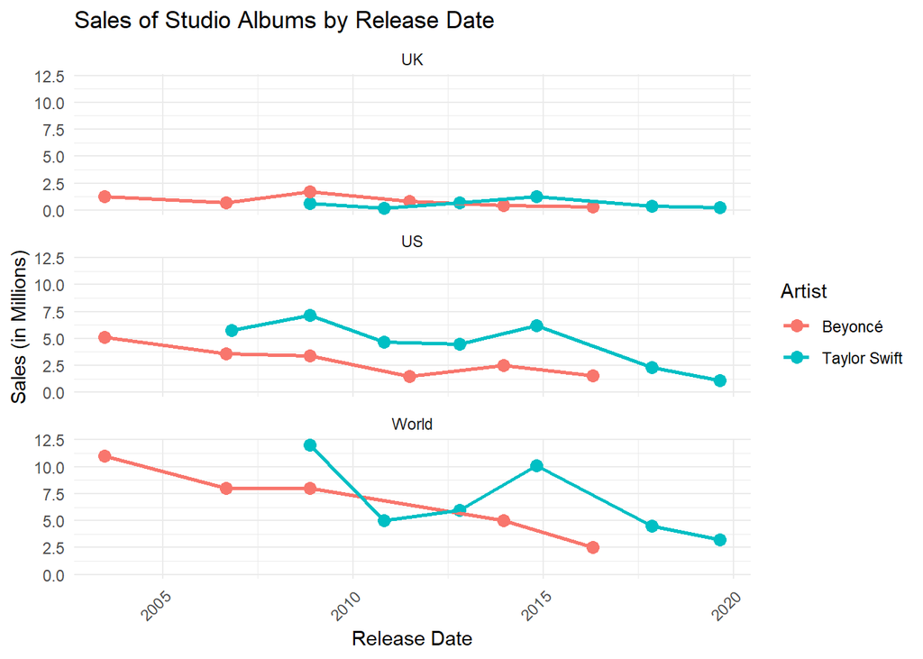

```r
# Create Scatter Plot

ggplot(filtered_sales, aes(x = released_date, y = sales_in_millions, color = artist)) +
  geom_point(size = 3) +  # Scatter plot points with size adjustment
  geom_line(size = 1) +   # Add lines connecting the points for each artist
  facet_wrap(~ country, nrow = 3) +  # Facet by Country into three rows
  labs(
    title = "Sales of Studio Albums by Release Date",
    x = "Release Date",
    y = "Sales (in Millions)",
    color = "Artist"
  ) +
  theme_minimal() +
  theme(axis.text.x = element_text(angle = 45, hjust = 1))  # Rotate x-axis labels for readability
```

# Part 2: Exploring sentiment of lyrics

In Part 2, we will explore the lyrics in the `b_lyrics` and `ts_lyrics` datasets.

## Part 2A

Using `ts_lyrics`, create a new column called `line` with one line containing the character string for each line of Taylor Swift’s songs.

- How many lines in Taylor Swift’s lyrics contain the word “hello”? For full credit, show all the rows in `ts_lyrics` that have “hello” in the `line` column and report how many rows there are in total.
- How many lines in Taylor Swift’s lyrics contain the word “goodbye”? For full credit, show all the rows in `ts_lyrics` that have “goodbye” in the `line` column and report how many rows there are in total.

```r
# Counting the number of times "hello" appears in Taylor Swift Songs
# Load necessary Libraries

library(dplyr)
library(tidyr)
library(tidytext)

# Step 1: Create a new column 'line' for each line of lyrics
ts_lines <- ts_lyrics %>%
  unnest_tokens(line, Lyrics, token = "lines")

# Step 2: Filter for lines containing "hello
hello_lines <- ts_lines %>%
  filter(grepl("hello", line, ignore.case = TRUE)) # Remove case-sensitivity

# Step 3: Display all rows containing hello and count total number of lines with hello
print(hello_lines)  # Display the rows
```

```
## # A tibble: 6 × 4
##   Artist       Album    Title                  line
##   <chr>        <chr>    <chr>                  <chr>
## 1 Taylor Swift Fearless Love Story             "and say, \"hello\""
## 2 Taylor Swift Red      I Almost Do            "that i can't say \"hello\" to y…
## 3 Taylor Swift Red      Everything Has Changed "'cause all i know is we said he…
## 4 Taylor Swift Red      Everything Has Changed "'cause all i know is we said he…
## 5 Taylor Swift Red      Everything Has Changed "all i know is we said hello"
## 6 Taylor Swift Red      Everything Has Changed "all i know is we said hello"
```

```r
n_hello_lines <- nrow(hello_lines)  # Count of lines with "hello"
cat("Number of lines containing 'hello':", n_hello_lines, "\n")
```

```
## Number of lines containing 'hello': 6
```

In total there are 6 lines that contain the word “Hello” in Taylor Swifts Songs

```r
# Counting the number of times "goodbye" appears in Taylor Swift Songs
# Filter for lines containing "goodbye"
goodbye_lines <- ts_lines %>%
  filter(grepl("goodbye", line, ignore.case = TRUE))  # Case-insensitive match

# Show all rows containing "goodbye" and count
print(goodbye_lines)  # Display the rows
```

```
## # A tibble: 12 × 4
##    Artist       Album        Title                      line
##    <chr>        <chr>        <chr>                      <chr>
##  1 Taylor Swift Taylor Swift Tied Together With A Smile "goodbye, baby"
##  2 Taylor Swift Speak Now    Mine                       "braced myself for the …
##  3 Taylor Swift Speak Now    Back to December           "you gave me all your l…
##  4 Taylor Swift Speak Now    Long Live                  "and force us into a go…
##  5 Taylor Swift Red          I Almost Do                "and risk another goodb…
##  6 Taylor Swift Red          Come Back Be Here          "stumbled through the l…
##  7 Taylor Swift 1989         All You Had to Do Was Stay "but people like me are…
##  8 Taylor Swift reputation   Getaway Car                "said goodbye in "
##  9 Taylor Swift reputation   Getaway Car                "said goodbye in "
## 10 Taylor Swift Lover        Death By A Thousand Cuts   "saying goodbye is deat…
## 11 Taylor Swift Lover        Death By A Thousand Cuts   "'cause saying goodbye …
## 12 Taylor Swift Lover        Daylight                   "i'll tell you truth, b…
```

```r
n_goodbye_lines <- nrow(goodbye_lines)  # Count of lines with "goodbye"
cat("Number of lines containing 'goodbye':", n_goodbye_lines, "\n")
```

```
## Number of lines containing 'goodbye': 12
```

In Total there are 12 lines that contain “Goodbye” in Taylor Swift’s Songs ## Part 2B

Repeat the same analysis for `b_lyrics` as described in Part 2A.

```r
# Counting the number of times "hello" appears in Beyonce Songs
# The Beyonce lyrics file is already separated into lines so there is no need to separate out the lines

# Step 1: Filter for lines containing "hello
hello_lines2 <- b_lyrics %>%
  filter(grepl("hello", line, ignore.case = TRUE)) # Remove case-sensitivity

# Step 2: Display all rows containing hello and count total number of lines with hello
print(hello_lines2)  # Display the rows
```

```
## # A tibble: 91 × 6
##    line                        song_id song_name artist_id artist_name song_line
##    <chr>                         <dbl> <chr>         <dbl> <chr>           <dbl>
##  1 Hello world, well I just b… 2220711 "Dreamgi…       498 Beyoncé             5
##  2 Hello Stevie, How you feel… 1981227 "Fingert…       498 Beyoncé             6
##  3 Fellow great Americans, he… 2715227 "FREEDOM…       498 Beyoncé            52
##  4 You had me at hello (Hello)   80249 "Hello"         498 Beyoncé            15
##  5 Hello (Hello)                 80249 "Hello"         498 Beyoncé            16
##  6 Hello (Hello)                 80249 "Hello"         498 Beyoncé            17
##  7 You had me at hello (Hello)   80249 "Hello"         498 Beyoncé            18
##  8 Hello (Hello)                 80249 "Hello"         498 Beyoncé            19
##  9 Hello (Hello)                 80249 "Hello"         498 Beyoncé            20
## 10 'Cause you had me at hello…   80249 "Hello"         498 Beyoncé            24
## # ℹ 81 more rows
```

```r
n_hello_lines2 <- nrow(hello_lines2)  # Count of lines with "hello"
cat("Number of lines containing 'hello':", n_hello_lines2, "\n")
```

```
## Number of lines containing 'hello': 91
```

The word “Hello” appears in 91 times in Beyonce songs.

```r
# Counting the number of times "Goodbye" appears in Beyonce Songs

# Filter for lines containing "goodbye"
goodbye_lines2 <- b_lyrics%>%
  filter(grepl("goodbye", line, ignore.case = TRUE))  # Case-insensitive match

# Show all rows containing "goodbye" and count
print(goodbye_lines2)  # Display the rows
```

```
## # A tibble: 12 × 6
##    line                        song_id song_name artist_id artist_name song_line
##    <chr>                         <dbl> <chr>         <dbl> <chr>           <dbl>
##  1 We only said goodbye with …  139043 Back to …       498 Beyoncé            12
##  2 We only said goodbye with …  139043 Back to …       498 Beyoncé            21
##  3 We only said goodbye with …  139043 Back to …       498 Beyoncé            24
##  4 Thank God, I found the goo…   51492 Best Thi…       498 Beyoncé            38
##  5 Thank God, I found the goo… 1946060 Best Thi…       498 Beyoncé            42
##  6 Thank God, I found the goo… 4241137 Best Thi…       498 Beyoncé            38
##  7 It's so hard to say goodbye  435491 Gift fro…       498 Beyoncé            23
##  8 I never want to say goodbye  435491 Gift fro…       498 Beyoncé            24
##  9 I never, ever want to say …  435491 Gift fro…       498 Beyoncé            25
## 10 We've got to say goodbye    1844620 Hard To …       498 Beyoncé            29
## 11 Don't have to say goodbye   1224115 Slow Love       498 Beyoncé            42
## 12 Somewhere between hi and g…  141848 Yes             498 Beyoncé            27
```

```r
num_goodbye_lines2 <- nrow(goodbye_lines2)  # Count of lines with "goodbye"
cat("Number of lines containing 'goodbye':", num_goodbye_lines2, "\n")
```

```
## Number of lines containing 'goodbye': 12
```

There are 12 lines in Beyonce songs that contain the word “Goodbye”. ## Part 2C

Using the `b_lyrics` dataset,

1. Tokenize each lyrical line by words.
2. Remove the “stopwords”.
3. Calculate the total number for each word in the lyrics.
4. Using the “bing” sentiment lexicon, add a column to the summarized data frame adding the “bing” sentiment lexicon.
5. Sort the rows from most frequent to least frequent words.
6. Only keep the top 25 most frequent words.
7. Auto print the wrangled tibble data frame.
8. Use `ggplot2` to create a bar plot with the top words on the y-axis and the frequency of each word on the x-axis. Color each bar by the sentiment of each word from the “bing” sentiment lexicon. Bars should be ordered from most frequent on the top to least frequent on the bottom of the plot.
9. Create a word cloud of the top 25 most frequent words.

```r
# Load necessary libraries
library(tidytext)
library(dplyr)
library(tidyr)

# Step 1: Token nice each lyrical line by words
b_words <- b_lyrics %>%
  unnest_tokens(word, line, token = "words")

print(b_words)
```

```
## # A tibble: 164,740 × 6
##    song_id song_name artist_id artist_name song_line word
##      <dbl> <chr>         <dbl> <chr>           <dbl> <chr>
##  1   50396 1+1             498 Beyoncé             1 if
##  2   50396 1+1             498 Beyoncé             1 i
##  3   50396 1+1             498 Beyoncé             1 ain't
##  4   50396 1+1             498 Beyoncé             1 got
##  5   50396 1+1             498 Beyoncé             1 nothing
##  6   50396 1+1             498 Beyoncé             1 i
##  7   50396 1+1             498 Beyoncé             1 got
##  8   50396 1+1             498 Beyoncé             1 you
##  9   50396 1+1             498 Beyoncé             2 if
## 10   50396 1+1             498 Beyoncé             2 i
## # ℹ 164,730 more rows
```

```r
# Step 2: Remove the "stopwords"

# Assess the built-in stopwords in the data set using tidytext
data("stop_words")

# Use the anti-join function to remove stopwords from the tokenized data set
b_words_filtered <- b_words %>%
  anti_join(stop_words, by = "word")

#View the tokenized data set without the stopwords
print(b_words_filtered)
```

```
## # A tibble: 55,471 × 6
##    song_id song_name artist_id artist_name song_line word
##      <dbl> <chr>         <dbl> <chr>           <dbl> <chr>
##  1   50396 1+1             498 Beyoncé             2 damn
##  2   50396 1+1             498 Beyoncé             4 algebra
##  3   50396 1+1             498 Beyoncé             4 1
##  4   50396 1+1             498 Beyoncé             4 1
##  5   50396 1+1             498 Beyoncé             4 equals
##  6   50396 1+1             498 Beyoncé             4 2
##  7   50396 1+1             498 Beyoncé             6 world
##  8   50396 1+1             498 Beyoncé             7 baby
##  9   50396 1+1             498 Beyoncé             7 love
## 10   50396 1+1             498 Beyoncé             8 darling
## # ℹ 55,461 more rows
```

```r
# Removing the stopwords reduced the data set by 109,269 lines
```

```r
# Step 3: Calculate the total number for each word in the lyrics

b_words_filtered <- b_words_filtered %>%
  count(word, sort = TRUE) # Count the occurrences of each word and sort them in descending order
```

```r
# Step 4: Using the "bing" sentiment lexicon add a column to the summarized dataframe

# Load the "bing" sentiment lexicon from tidytext
bing_sentiments <- get_sentiments("bing")

# Join the bing sentiment lexicon to the tokenized dataset
b_sentiment <- b_words_filtered %>%
  inner_join(bing_sentiments, by = "word")

# View the data frame to check that sentiment annotation is functioning correctly
print(b_sentiment)
```

```
## # A tibble: 800 × 3
##    word          n sentiment
##    <chr>     <int> <chr>
##  1 love       1362 positive
##  2 crazy       308 negative
##  3 top         241 positive
##  4 bad         132 negative
##  5 beautiful   131 positive
##  6 whoa        121 positive
##  7 damn        106 negative
##  8 hurt         90 negative
##  9 hard         87 negative
## 10 ready        85 positive
## # ℹ 790 more rows
```

```r
# Step 5: Sort the rows from most frequent to least frequent words
# words are already sorted in descending order after step 3

# Step 6: Only keep the top 25 most frequently used words
# Step 6: Only keep the top 25 most frequently used words
b_sentiment <- b_sentiment %>%
  slice_head(n=25)

# Step 7: Autoprint the truncated b_sentiment dataframe
b_sentiment
```

```
## # A tibble: 25 × 3
##    word          n sentiment
##    <chr>     <int> <chr>
##  1 love       1362 positive
##  2 crazy       308 negative
##  3 top         241 positive
##  4 bad         132 negative
##  5 beautiful   131 positive
##  6 whoa        121 positive
##  7 damn        106 negative
##  8 hurt         90 negative
##  9 hard         87 negative
## 10 ready        85 positive
## # ℹ 15 more rows
```

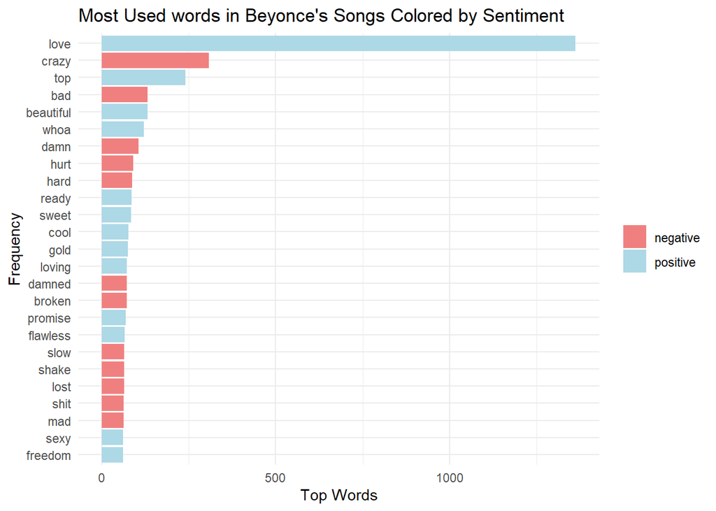

```r
# Step 8: Create a bar plot of the top words color coded by sentiment
ggplot(b_sentiment, aes(x = reorder(word, n), y = n, fill = sentiment)) +
  geom_bar(stat = "identity") +
  coord_flip() +  # Flip coordinates for better readability
  labs(x = "Frequency", y = "Top Words", title = "Most Used words in Beyonce's Songs Colored by Sentiment") +
  theme_minimal() +
  scale_fill_manual(values = c("positive" = "lightblue", "negative" = "lightcoral")) +  # Customize colors for sentiments
  theme(legend.title = element_blank())  # Remove legend title
```

```r
# Step 9: Create a Word Cloud of the most frequently used words in Beyonce lyrics

# Install & load necessary package

library(wordcloud2)

wordcloud2(b_sentiment,
        size = 1,          # Size of the words in the cloud
        minSize = 0.5,    # Minimum size of the smallest words
        color = 'random-light',  # Color scheme for the words
        backgroundColor = 'white',  # Background color of the word cloud
        shape = 'circle')  # Shape of the word cloud )
```

[interactive chart not shown]

## Part 2D

Repeat the same analysis as above in Part 2C, but for `ts_lyrics`.

```r
# Load necessary libraries
library(tidytext)
library(dplyr)
library(tidyr)

# Step 1: Token nice each lyrical line by words
ts_words <- ts_lines %>%
  unnest_tokens(word, line, token = "words")

print(ts_words)
```

```
## # A tibble: 48,555 × 4
##    Artist       Album        Title      word
##    <chr>        <chr>        <chr>      <chr>
##  1 Taylor Swift Taylor Swift Tim McGraw he
##  2 Taylor Swift Taylor Swift Tim McGraw said
##  3 Taylor Swift Taylor Swift Tim McGraw the
##  4 Taylor Swift Taylor Swift Tim McGraw way
##  5 Taylor Swift Taylor Swift Tim McGraw my
##  6 Taylor Swift Taylor Swift Tim McGraw blue
##  7 Taylor Swift Taylor Swift Tim McGraw eyes
##  8 Taylor Swift Taylor Swift Tim McGraw shinx
##  9 Taylor Swift Taylor Swift Tim McGraw put
## 10 Taylor Swift Taylor Swift Tim McGraw those
## # ℹ 48,545 more rows
```

```r
# Step 2: Remove the "stopwords"

# Assess the built-in stopwords in the data set using tidytext
data("stop_words")

# Use the anti-join function to remove stopwords from the tokenized data set
ts_words_filtered <- ts_words %>%
  anti_join(stop_words, by = "word")

#View the tokenized data set without the stopwords
print(ts_words_filtered)
```

```
## # A tibble: 13,097 × 4
##    Artist       Album        Title      word
##    <chr>        <chr>        <chr>      <chr>
##  1 Taylor Swift Taylor Swift Tim McGraw blue
##  2 Taylor Swift Taylor Swift Tim McGraw eyes
##  3 Taylor Swift Taylor Swift Tim McGraw shinx
##  4 Taylor Swift Taylor Swift Tim McGraw georgia
##  5 Taylor Swift Taylor Swift Tim McGraw stars
##  6 Taylor Swift Taylor Swift Tim McGraw shame
##  7 Taylor Swift Taylor Swift Tim McGraw night
##  8 Taylor Swift Taylor Swift Tim McGraw lie
##  9 Taylor Swift Taylor Swift Tim McGraw boy
## 10 Taylor Swift Taylor Swift Tim McGraw chevy
## # ℹ 13,087 more rows
```

```r
# Removing the stopwords reduced the data set by 35,458 lines
```

```r
# Step 3: Calculate the total number for each word in the lyrics

ts_words_filtered <- ts_words_filtered %>%
  count(word, sort = TRUE) # Count the occurrences of each word and sort them in descending order

# Step 4: Using the "bing" sentiment lexicon add a column to the summarized dataframe

# Load the "bing" sentiment lexicon from tidytext
bing_sentiments <- get_sentiments("bing")

# Join the bing sentiment lexicon to the tokenized dataset
ts_sentiment <- ts_words_filtered %>%
  inner_join(bing_sentiments, by = "word")

# View the data frame to check that sentiment annotation is functioning correctly
print(ts_sentiment)
```

```
## # A tibble: 491 × 3
##    word          n sentiment
##    <chr>     <int> <chr>
##  1 love        248 positive
##  2 bad          80 negative
##  3 shake        73 negative
##  4 break        59 negative
##  5 mad          48 negative
##  6 beautiful    46 positive
##  7 smile        45 positive
##  8 hate         44 negative
##  9 fall         43 negative
## 10 whoa         36 positive
## # ℹ 481 more rows
```

```r
# Step 5: Sort the rows from most frequent to least frequent words
# words are already sorted in descending order after step 3

# Step 6: Only keep the top 25 most frequently used words
# Step 6: Only keep the top 25 most frequently used words
ts_sentiment <- ts_sentiment %>%
  slice_head(n=25)

# Step 7: Autoprint the truncated b_sentiment dataframe
ts_sentiment
```

```
## # A tibble: 25 × 3
##    word          n sentiment
##    <chr>     <int> <chr>
##  1 love        248 positive
##  2 bad          80 negative
##  3 shake        73 negative
##  4 break        59 negative
##  5 mad          48 negative
##  6 beautiful    46 positive
##  7 smile        45 positive
##  8 hate         44 negative
##  9 fall         43 negative
## 10 whoa         36 positive
## # ℹ 15 more rows
```

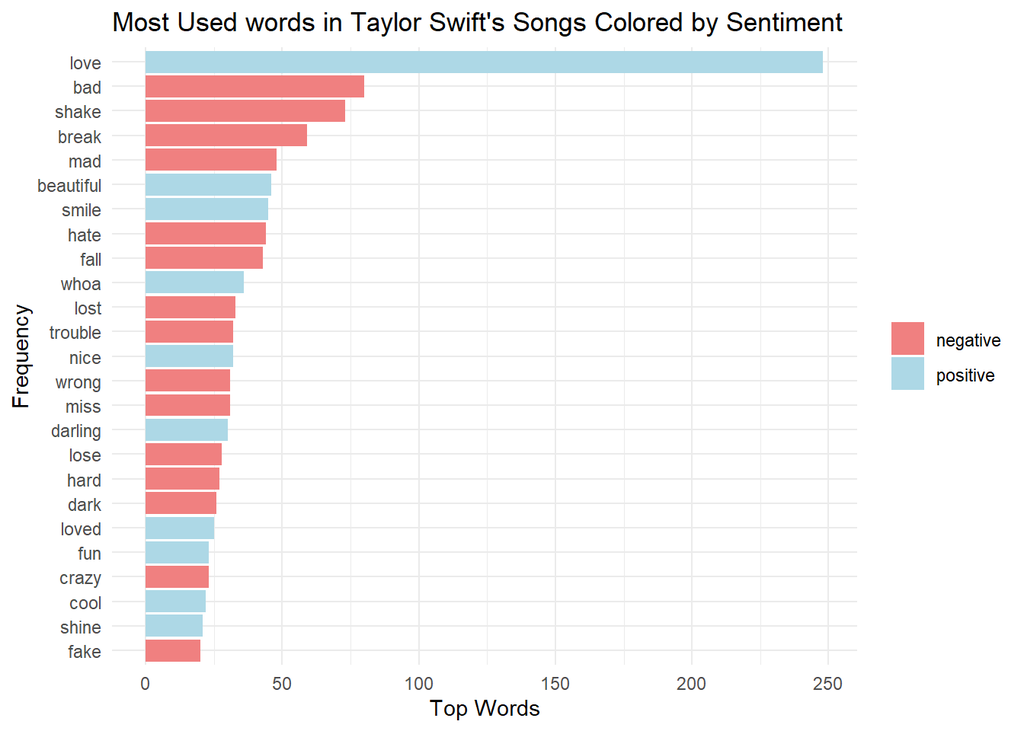

```r
# Step 8: Create a bar plot of the top words color coded by sentiment
ggplot(ts_sentiment, aes(x = reorder(word, n), y = n, fill = sentiment)) +
  geom_bar(stat = "identity") +
  coord_flip() +  # Flip coordinates for better readability
  labs(x = "Frequency", y = "Top Words", title = "Most Used words in Taylor Swift's Songs Colored by Sentiment") +
  theme_minimal() +
  scale_fill_manual(values = c("positive" = "lightblue", "negative" = "lightcoral")) +  # Customize colors for sentiments
  theme(legend.title = element_blank())  # Remove legend title
```

```r
# Step 9: Create a Word Cloud of the most frequently used words in Beyonce lyrics
library(wordcloud2)

wordcloud2(ts_sentiment,
        size = 1,          # Size of the words in the cloud
        minSize = 0.5,    # Minimum size of the smallest words
        color = 'random-light',  # Color scheme for the words
        backgroundColor = 'white',  # Background color of the word cloud
        shape = 'circle')  # Shape of the word cloud )
```

[interactive chart not shown]

## Part 2E

Using the `ts_lyrics` dataset,

1. Tokenize each lyrical line by words.
2. Remove the “stopwords”.
3. Calculate the total number for each word in the lyrics **for each Album**.
4. Using the “afinn” sentiment lexicon, add a column to the summarized data frame adding the “afinn” sentiment lexicon.
5. Calculate the average sentiment score **for each Album**.
6. Auto print the wrangled tibble data frame.
7. Join the wrangled data frame from Part 1A (album sales in millions) filtered down to US sales with the wrangled data frame from #6 above (average sentiment score for each album).
8. Using `ggplot2`, create a scatter plot of the average sentiment score for each album (y-axis) and the album release data along the x-axis. Make the size of each point the album sales in millions.
9. Add a horizontal line at y-intercept=0.
10. Write 2-3 sentences interpreting the plot answering the question “How has the sentiment of Taylor Swift’s albums have changed over time?”. Add a title, subtitle, and useful axis labels.

```r
# Load necessary libraries
library(dplyr)
library(tidytext)

# Step 1: Tokenize each lyrical line into words, preserving the 'Album' column
ts_words_by_album <- ts_lyrics %>%
  unnest_tokens(word, Lyrics, token = "words")  # Tokenizing Lyrics by words

# Step 2: Remove stopwords
data("stop_words")
ts_words_by_album <- ts_words_by_album %>%
  anti_join(stop_words, by = "word")  # Remove stopwords

print(ts_words_by_album)
```

```
## # A tibble: 13,097 × 4
##    Artist       Album        Title      word
##    <chr>        <chr>        <chr>      <chr>
##  1 Taylor Swift Taylor Swift Tim McGraw blue
##  2 Taylor Swift Taylor Swift Tim McGraw eyes
##  3 Taylor Swift Taylor Swift Tim McGraw shinx
##  4 Taylor Swift Taylor Swift Tim McGraw georgia
##  5 Taylor Swift Taylor Swift Tim McGraw stars
##  6 Taylor Swift Taylor Swift Tim McGraw shame
##  7 Taylor Swift Taylor Swift Tim McGraw night
##  8 Taylor Swift Taylor Swift Tim McGraw lie
##  9 Taylor Swift Taylor Swift Tim McGraw boy
## 10 Taylor Swift Taylor Swift Tim McGraw chevy
## # ℹ 13,087 more rows
```

```r
# Step 3: Calculate the total number of occurrences for each word in each Album

word_counts_by_album <- ts_words_by_album %>%
  count(Album, word, name = "total_occurrences", sort = TRUE)

# Merge the word counts back to the original dataset to retain all information
ts_filtered_dataset <- ts_lyrics %>%
  left_join(word_counts_by_album, by = "Album")
# View datsets to ensure merger went well
print(head(ts_lyrics))         # Original dataset
```

```
## # A tibble: 6 × 4
##   Artist       Album        Title                  Lyrics
##   <chr>        <chr>        <chr>                  <chr>
## 1 Taylor Swift Taylor Swift Tim McGraw             "He said the way my blue eye…
## 2 Taylor Swift Taylor Swift Picture to Burn        "State the obvious, I didn't…
## 3 Taylor Swift Taylor Swift Teardrops on my Guitar "Drew looks at me,\nI fake a…
## 4 Taylor Swift Taylor Swift A Place in This World  "I don't know what I want, s…
## 5 Taylor Swift Taylor Swift Cold As You            "You have a way of coming ea…
## 6 Taylor Swift Taylor Swift The Outside            "I didn't know what I would …
```

```r
print(head(word_counts_by_album))  # Word counts by album
```

```
## # A tibble: 6 × 3
##   Album word  total_occurrences
##   <chr> <chr>             <int>
## 1 1989  love                 82
## 2 1989  shake                70
## 3 Red   time                 66
## 4 Lover ooh                  61
## 5 Red   uh                   50
## 6 Red   red                  46
```

```r
print(head(ts_filtered_dataset))      # Merged dataset with word counts
```

```
## # A tibble: 6 × 6
##   Artist       Album        Title      Lyrics            word  total_occurrences
##   <chr>        <chr>        <chr>      <chr>             <chr>             <int>
## 1 Taylor Swift Taylor Swift Tim McGraw "He said the way… wanna                24
## 2 Taylor Swift Taylor Swift Tim McGraw "He said the way… love                 20
## 3 Taylor Swift Taylor Swift Tim McGraw "He said the way… shou…                20
## 4 Taylor Swift Taylor Swift Tim McGraw "He said the way… beau…                17
## 5 Taylor Swift Taylor Swift Tim McGraw "He said the way… baby                 15
## 6 Taylor Swift Taylor Swift Tim McGraw "He said the way… song                 15
```

```r
# Step 4: USe the "afinn" sentiment lexicon, and add a column to the summarized dataframe
library(textdata)

# Load the Afinn lexicon
afinn <- get_sentiments("afinn")

# Join the Afinn lexicon with the ts_filtered_dataset
ts_filtered_with_sentiment <- ts_filtered_dataset %>%
  left_join(afinn, by = "word") #Join by word to add sentiment scores

# View just the first few rows to ensure join was successful
print(head(ts_filtered_with_sentiment))
```

```
## # A tibble: 6 × 7
##   Artist       Album        Title      Lyrics      word  total_occurrences value
##   <chr>        <chr>        <chr>      <chr>       <chr>             <int> <dbl>
## 1 Taylor Swift Taylor Swift Tim McGraw "He said t… wanna                24    NA
## 2 Taylor Swift Taylor Swift Tim McGraw "He said t… love                 20     3
## 3 Taylor Swift Taylor Swift Tim McGraw "He said t… shou…                20    NA
## 4 Taylor Swift Taylor Swift Tim McGraw "He said t… beau…                17     3
## 5 Taylor Swift Taylor Swift Tim McGraw "He said t… baby                 15    NA
## 6 Taylor Swift Taylor Swift Tim McGraw "He said t… song                 15    NA
```

```r
# Step 5: Calculate the average sentiment score for each album

ts_average_sentiment_by_album <- ts_filtered_with_sentiment %>%
  group_by(Album) %>%
  summarize(average_Sentiment = mean(value, na.rm = TRUE)) # Calculate the mean, while ignoring NA values

# Look at the sentiment scores
print(ts_average_sentiment_by_album)
```

```
## # A tibble: 8 × 2
##   Album        average_Sentiment
##   <chr>                    <dbl>
## 1 1989                  -0.822
## 2 Fearless               0.0192
## 3 Lover                 -0.429
## 4 Red                   -0.00870
## 5 Speak Now             -0.365
## 6 Taylor Swift           0.137
## 7 folklore              -0.613
## 8 reputation            -0.495
```

```r
# Step 7: Join the US sales data set with the average sentiment data set
combined_sales_sentiment <- US_sales %>%
  left_join(ts_average_sentiment_by_album, by = c("title" = "Album")) # Join by Album, the c= specifies by which column since the columns are named differently in each column.

# Check join on combined data set
print(combined_sales_sentiment)
```

```
## # A tibble: 13 × 13
##    artist       title           country  sales released re_release label formats
##    <chr>        <chr>           <fct>    <dbl> <chr>    <chr>      <chr> <chr>
##  1 Taylor Swift Taylor Swift    US      5.72e6 October… March 18,… Big … CD, CD…
##  2 Taylor Swift Fearless        US      7.18e6 Novembe… October 2… Big … CD, CD…
##  3 Taylor Swift Speak Now       US      4.69e6 October… <NA>       Big … CD, CD…
##  4 Taylor Swift Red             US      4.47e6 October… <NA>       Big … CD, CD…
##  5 Taylor Swift 1989            US      6.21e6 October… <NA>       Big … CD, CD…
##  6 Taylor Swift Reputation      US      2.3 e6 Novembe… <NA>       Big … CD, CD…
##  7 Taylor Swift Lover           US      1.09e6 August … <NA>       Repu… CD, LP…
##  8 Beyoncé      Dangerously in… US      5.10e6 June 23… <NA>       Colu… CD, LP…
##  9 Beyoncé      B'Day           US      3.61e6 Septemb… <NA>       Sony… CD, CD…
## 10 Beyoncé      I Am... Sasha … US      3.38e6 Novembe… <NA>       Musi… CD, CD…
## 11 Beyoncé      4               US      1.5 e6 June 24… <NA>       Park… CD, di…
## 12 Beyoncé      Beyoncé         US      2.51e6 Decembe… <NA>       Park… CD, CD…
## 13 Beyoncé      Lemonade        US      1.55e6 April 2… <NA>       Park… CD/DVD…
## # ℹ 5 more variables: cleaned_released <chr>, released_date <date>,
## #   sales_in_millions <dbl>, years_since_release <dbl>, average_Sentiment <dbl>
```

```r
# Filter out data to only keep the taylor swift data
taylor_only_combined <- combined_sales_sentiment %>%
  filter(artist == "Taylor Swift")

# Check if filtering was successful
print(taylor_only_combined)
```

```
## # A tibble: 7 × 13
##   artist title country  sales released re_release label formats cleaned_released
##   <chr>  <chr> <fct>    <dbl> <chr>    <chr>      <chr> <chr>   <chr>
## 1 Taylo… Tayl… US      5.72e6 October… March 18,… Big … CD, CD… October 24, 2006
## 2 Taylo… Fear… US      7.18e6 Novembe… October 2… Big … CD, CD… November 11, 20…
## 3 Taylo… Spea… US      4.69e6 October… <NA>       Big … CD, CD… October 25, 2010
## 4 Taylo… Red   US      4.47e6 October… <NA>       Big … CD, CD… October 22, 2012
## 5 Taylo… 1989  US      6.21e6 October… <NA>       Big … CD, CD… October 27, 2014
## 6 Taylo… Repu… US      2.3 e6 Novembe… <NA>       Big … CD, CD… November 10, 20…
## 7 Taylo… Lover US      1.09e6 August … <NA>       Repu… CD, LP… August 23, 2019
## # ℹ 4 more variables: released_date <date>, sales_in_millions <dbl>,
## #   years_since_release <dbl>, average_Sentiment <dbl>
```

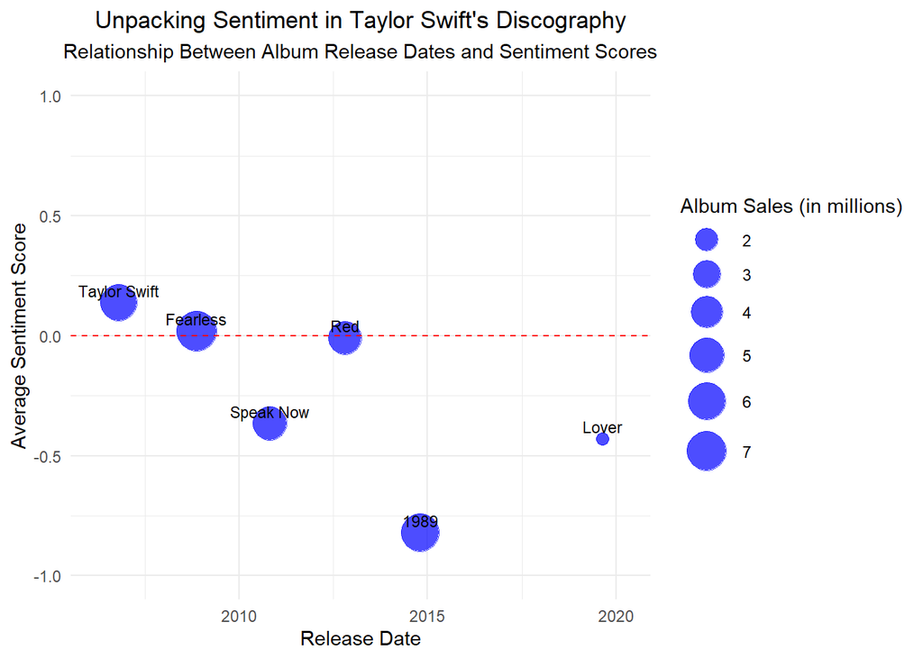

```r
# Step 8: Create a scatter plot of the average sentiment score for each album

ggplot(taylor_only_combined, aes(x = released_date, y = average_Sentiment, size = sales_in_millions, label = title)) +
  geom_point(alpha = 0.7, color = "blue") +  # Set point transparency and color
  geom_hline(yintercept = 0, linetype = "dashed", color = "red") +  # Add horizontal line at y=0
  geom_text(vjust = -0.5, size = 3, check_overlap = TRUE) +  # Add album names above points
  scale_size_continuous(name = "Album Sales (in millions)", range = c(3, 10)) +  # Customize size legend
  scale_y_continuous(limits = c(-1, 1)) +  # Adjust y-axis limits to prevent cutoff
  scale_x_date(expand = expansion(mult = c(0.1, 0.1))) +  # Add padding to x-axis
  labs(
    title = "Unpacking Sentiment in Taylor Swift's Discography",
    subtitle = "Relationship Between Album Release Dates and Sentiment Scores",
    x = "Release Date",
    y = "Average Sentiment Score"
  ) +
  theme_minimal() +  # Use a minimal theme for a clean look
  theme(
    plot.title = element_text(hjust = 0.5),  # Center the title
    plot.subtitle = element_text(hjust = 0.5)  # Center the subtitle

  )
```

```r
options(width = 120)
```

[session information not shown]